# Motor Trend Cars Test Analysis

Halley Wang

December 26, 2015

```r
## Loading the necessary packages
library(ggplot2)
library(dplyr)
library(grid)
library(gridExtra)
```

#### Variable plot

First we test the relationship of all variables on the response mpg:

```r
head(mtcars)
```

```
##                    mpg cyl disp  hp drat    wt  qsec vs am gear carb
## Mazda RX4         21.0   6  160 110 3.90 2.620 16.46  0  1    4    4
## Mazda RX4 Wag     21.0   6  160 110 3.90 2.875 17.02  0  1    4    4
## Datsun 710        22.8   4  108  93 3.85 2.320 18.61  1  1    4    1
## Hornet 4 Drive    21.4   6  258 110 3.08 3.215 19.44  1  0    3    1
## Hornet Sportabout 18.7   8  360 175 3.15 3.440 17.02  0  0    3    2
## Valiant           18.1   6  225 105 2.76 3.460 20.22  1  0    3    1
```

```r
## All variables
lmMPG_all = lm(mpg ~ ., data = mtcars)
summary(lmMPG_all)$coefficients
```

```
##                Estimate  Std. Error    t value   Pr(>|t|)
## (Intercept) 12.30337416 18.71788443  0.6573058 0.51812440
## cyl         -0.11144048  1.04502336 -0.1066392 0.91608738
## disp         0.01333524  0.01785750  0.7467585 0.46348865
## hp          -0.02148212  0.02176858 -0.9868407 0.33495531
## drat         0.78711097  1.63537307  0.4813036 0.63527790
## wt          -3.71530393  1.89441430 -1.9611887 0.06325215
## qsec         0.82104075  0.73084480  1.1234133 0.27394127
## vs           0.31776281  2.10450861  0.1509915 0.88142347
## am           2.52022689  2.05665055  1.2254035 0.23398971
## gear         0.65541302  1.49325996  0.4389142 0.66520643
## carb        -0.19941925  0.82875250 -0.2406258 0.81217871
```

As we can see the p-values in the summary, wt has the least p-values and therefore the most significant impact on the response mpg.

```r
## We want to study the relationship between the miles per gallon with the transmission type and the weight:
lmMPG_main = with(mtcars, lm(mpg ~ factor(am) + wt))
lmMPG_interact = with(mtcars, lm(mpg ~ factor(am) * wt))

anova(lmMPG_main, lmMPG_interact)
```

```
## Analysis of Variance Table
##
## Model 1: mpg ~ factor(am) + wt
## Model 2: mpg ~ factor(am) * wt
##   Res.Df    RSS Df Sum of Sq     F   Pr(>F)
## 1     29 278.32
## 2     28 188.01  1    90.312 13.45 0.001017 **
## ---
## Signif. codes:  0 '***' 0.001 '**' 0.01 '*' 0.05 '.' 0.1 ' ' 1
```

As we can see from the ANOVA result, the interacton term is significant for the result mpg, which means that the effect of weight on two transmission type is different. Therefore we use the interaction model.

#### Coefficients explanation

```r
summary(lmMPG_interact)$coefficients
```

```
##                 Estimate Std. Error   t value     Pr(>|t|)
## (Intercept)    31.416055  3.0201093 10.402291 4.001043e-11
## factor(am)1    14.878423  4.2640422  3.489277 1.621034e-03
## wt             -3.785908  0.7856478 -4.818836 4.551182e-05
## factor(am)1:wt -5.298360  1.4446993 -3.667449 1.017148e-03
```

```r
coef(lmMPG_interact)
```

```
##    (Intercept)    factor(am)1             wt factor(am)1:wt
##      31.416055      14.878423      -3.785908      -5.298360
```

As we can see from the summary, all coefficients have very small p-values, and therefore are significant on the result.

For level am=0 (automatic transmission), the mean response function for mpg is Intercept + wt * weight, which is 31.4160554 + -3.7859075 * weight.

In conclusion, for Automatic transmission, each 1000 pound will reduce 3.7859075 loss in mpg, for manual transmission, each 1000 pound will reduce 9.084268 loss in mpg.

#### Summary

As we can see from the residual plot (Appendix II), there is no significant patterns.

```r
g1 = ggplot(data = mtcars, aes(x = wt, y = mpg, color = factor(am)))
g1 = g1 + geom_point() + geom_smooth(method = "lm")
g1 = g1 + labs(title = "Appendix I: wt on mpg for different transmissions", x = "Weight(1000lb)", y = "mpg (miles per gallon)")
```

#### Appendix II: residual plot

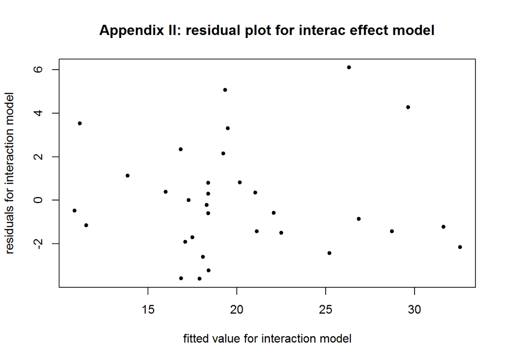

```r
## Residual plot: fitted values verses Residuals:
plot(x = fitted.values(lmMPG_interact), y = resid(lmMPG_interact), pch = 20, xlab = "fitted value for interaction model", ylab = "residuals for interaction model", main = "Appendix II: residual plot for interac effect model")
```